# Examining DESSA

Authors: Thao Trann (and some Neil)

# Introduction

This Document was created on 05/31/2018 By Thao Trann. There have been additions made by Neil Yetz. The goal of this project is to evaluate and factor analyze The Devereux Student Strengths Assessment (DESSA) scale.The researchers hope to understand the internal structure of the DESSA and its corresponding subcomponents. The DESSA scale was administered at Pre-intervention (“time 0”), at the end of the intervention (week 11; to be referred to as “time 1”) and at a 6 month follow-up to the interventions (“time 2”). This document was last updated on May 31, 2018 at 1:35:43 PM by ndyetz.

## Instrument Information

**Instrument Citation**

LeBuffe, P. A., Shapiro, V. B., & Naglieri, J. A. (2009, 2014). The Devereux Student Strengths Assessment (DESSA). Charlotte, NC: Apperson.

**Description of Instrument**

The DESSA is composed of seven subscales: Decision Making, Goal-Directed Behavior, Optimistic Thinking, Personal Responsibility, Relationship Skills, Self Awareness, and Self Management. The instrument is available at intake (p0), at the end of CC (p1), and at the six month follow-up (p2).

# Load libraries

```r
#Clear Environment
rm(list=ls(all=TRUE))
library(tidyverse)
library(psych)
library(lavaan)
library(semTools)
library(GPArotation)
```

# Read in data

```r
data <- read_csv("PARENTSURVEY.csv")
#dataF15 <- data[1:127,]
dataF15 <- data %>%
  filter(semester == "F15")
```

# Select relevant variables

```r
#Pre-intervention
dessa.time0 <- dataF15 %>%
  select(p0dessa_1:p0dessa_76) %>%
  na.omit()
#End of intervention
dessa.time1 <- dataF15 %>%
  select(p1dessa_1:p1dessa_76) %>%
  na.omit()
#6 months post-intervention
dessa.time2 <- dataF15 %>%
  select(p2dessa_1:p2dessa_76) %>%
  na.omit()
```

# Conduct Factor Analysis to re-test the DESSA structure

DESSA was designed as a multidimension scale with 7 subscales: Decision Making, Goal-Directed Behavior, Optimistic Thinking, Personal Responsibility, Relationship Skills, Self Awareness, and Self Management. We will fit a CFA model with 7 factors and examine the fit statistics of this model.

## CFA with 7 factors (using dessa pre-intervention)

```r
model.7f <- 'f1 =~ NA*p0dessa_57 + p0dessa_58 + p0dessa_36 + p0dessa_41 + p0dessa_71 + p0dessa_48 + p0dessa_49 + p0dessa_73
  f2 =~ NA*p0dessa_17 + p0dessa_20 + p0dessa_6 + p0dessa_22 + p0dessa_7 + p0dessa_9 + p0dessa_23 + p0dessa_13 + p0dessa_30 + p0dessa_55
  f3 =~ NA*p0dessa_1 + p0dessa_18 + p0dessa_5 + p0dessa_8 + p0dessa_15 + p0dessa_33 + p0dessa_19
  f4 =~ NA*p0dessa_16 + p0dessa_2 + p0dessa_3 + p0dessa_10 + p0dessa_26 + p0dessa_27 + p0dessa_12 + p0dessa_14 + p0dessa_56 + p0dessa_53
  f5 =~ NA*p0dessa_34 + p0dessa_35 + p0dessa_61 + p0dessa_62 + p0dessa_69 + p0dessa_40 + p0dessa_66 + p0dessa_47 + p0dessa_50 + p0dessa_74
  f6 =~ NA*p0dessa_59 + p0dessa_63 + p0dessa_67 + p0dessa_44 + p0dessa_68 + p0dessa_46 + p0dessa_70
  f7 =~ NA*p0dessa_31 + p0dessa_60 + p0dessa_37 + p0dessa_38 + p0dessa_39 + p0dessa_64 + p0dessa_65 + p0dessa_42 + p0dessa_43 + p0dessa_45 + p0dessa_72 + p0dessa_51
  f1 ~~ 1*f1
  f2 ~~ 1*f2
  f3 ~~ 1*f3
  f4 ~~ 1*f4
  f5 ~~ 1*f5
  f6 ~~ 1*f6
  f7 ~~ 1*f7'
    fit.model.7f <- cfa(model.7f, dessa.time0)
summary(fit.model.7f, fit.measures = TRUE, standardized = TRUE)
```

```
lavaan (0.5-23.1097) converged normally after  64 iterations

  Number of observations                           121

  Estimator                                         ML
  Minimum Function Test Statistic             4014.592
  Degrees of freedom                              1931
  P-value (Chi-square)                           0.000

Model test baseline model:

  Minimum Function Test Statistic             8130.946
  Degrees of freedom                              2016
  P-value                                        0.000

User model versus baseline model:

  Comparative Fit Index (CFI)                    0.659
  Tucker-Lewis Index (TLI)                       0.644

Loglikelihood and Information Criteria:

  Loglikelihood user model (H0)              -8435.905
  Loglikelihood unrestricted model (H1)      -6428.609

  Number of free parameters                        149
  Akaike (AIC)                               17169.810
  Bayesian (BIC)                             17586.383
  Sample-size adjusted Bayesian (BIC)        17115.296

Root Mean Square Error of Approximation:

  RMSEA                                          0.094
  90 Percent Confidence Interval          0.090  0.099
  P-value RMSEA <= 0.05                          0.000

Standardized Root Mean Square Residual:

  SRMR                                           0.080

```

[output cut: 167 more lines]

```
   .p0dessa_68        0.546    0.076    7.152    0.000    0.546    0.567
   .p0dessa_46        0.784    0.103    7.582    0.000    0.784    0.800
   .p0dessa_70        0.563    0.074    7.627    0.000    0.563    0.838
   .p0dessa_31        0.688    0.091    7.538    0.000    0.688    0.661
   .p0dessa_60        0.331    0.046    7.166    0.000    0.331    0.435
   .p0dessa_37        0.572    0.077    7.444    0.000    0.572    0.584
   .p0dessa_38        0.445    0.061    7.293    0.000    0.445    0.492
   .p0dessa_39        0.349    0.048    7.290    0.000    0.349    0.491
   .p0dessa_64        0.503    0.069    7.275    0.000    0.503    0.483
   .p0dessa_65        0.365    0.051    7.146    0.000    0.365    0.428
   .p0dessa_42        0.634    0.085    7.483    0.000    0.634    0.613
   .p0dessa_43        0.394    0.053    7.501    0.000    0.394    0.628
   .p0dessa_45        0.378    0.051    7.432    0.000    0.378    0.575
   .p0dessa_72        0.563    0.075    7.500    0.000    0.563    0.627
   .p0dessa_51        0.366    0.050    7.369    0.000    0.366    0.535
```

```r
resid(fit.model.7f, type ="cor")
```

[output not shown]

[output cut: 8 more lines]

[output not shown]

```r
reliability(fit.model.7f)
```

```
              f1        f2        f3        f4        f5        f6        f7     total
alpha  0.8943784 0.9051594 0.8351024 0.8863747 0.9159660 0.7909551 0.9053905 0.9772454
omega  0.8997646 0.9063352 0.8431619 0.8872448 0.9183047 0.7868152 0.9070688 0.9794590
omega2 0.8997646 0.9063352 0.8431619 0.8872448 0.9183047 0.7868152 0.9070688 0.9794590
omega3 0.9103656 0.9043890 0.8497217 0.8856316 0.9210008 0.7689716 0.9102656 0.9650693
avevar 0.5335444 0.4957632 0.4438443 0.4435450 0.5334806 0.3530275 0.4516087 0.4677252
```

```r
alpha(dessa.time0)
```

```
Reliability analysis
Call: alpha(x = dessa.time0)

  raw_alpha std.alpha G6(smc) average_r S/N    ase mean  sd
      0.98      0.98       1       0.4  51 0.0025  3.3 0.6

 lower alpha upper     95% confidence boundaries
0.98 0.98 0.99

 Reliability if an item is dropped:
           raw_alpha std.alpha G6(smc) average_r S/N alpha se
p0dessa_1       0.98      0.98    1.00       0.4  51   0.0025
p0dessa_2       0.98      0.98    1.00       0.4  50   0.0026
p0dessa_3       0.98      0.98    1.00       0.4  50   0.0026
p0dessa_4       0.98      0.98    0.99       0.4  50   0.0026
p0dessa_5       0.98      0.98    1.00       0.4  51   0.0025
p0dessa_6       0.98      0.98    0.99       0.4  50   0.0026
p0dessa_7       0.98      0.98    1.00       0.4  50   0.0026
p0dessa_8       0.98      0.98    1.00       0.4  50   0.0026
p0dessa_9       0.98      0.98    1.00       0.4  50   0.0026
p0dessa_10      0.98      0.98    0.99       0.4  50   0.0026
p0dessa_11      0.98      0.98    1.00       0.4  50   0.0026
p0dessa_12      0.98      0.98    1.00       0.4  51   0.0025
p0dessa_13      0.98      0.98    0.99       0.4  50   0.0026
p0dessa_14      0.98      0.98    0.99       0.4  50   0.0026
p0dessa_15      0.98      0.98    0.99       0.4  50   0.0026
p0dessa_16      0.98      0.98    0.99       0.4  50   0.0026
p0dessa_17      0.98      0.98    0.99       0.4  49   0.0026
p0dessa_18      0.98      0.98    0.99       0.4  50   0.0026
p0dessa_19      0.98      0.98    0.99       0.4  50   0.0026
p0dessa_20      0.98      0.98    0.99       0.4  50   0.0026
p0dessa_21      0.98      0.98    0.99       0.4  50   0.0026
p0dessa_22      0.98      0.98    0.99       0.4  50   0.0026
p0dessa_23      0.98      0.98    1.00       0.4  50   0.0026
p0dessa_24      0.98      0.98    0.99       0.4  50   0.0026
p0dessa_25      0.98      0.98    1.00       0.4  50   0.0026
p0dessa_26      0.98      0.98    0.99       0.4  50   0.0026
p0dessa_27      0.98      0.98    0.99       0.4  50   0.0026
p0dessa_28      0.98      0.98    0.99       0.4  50   0.0026
p0dessa_29      0.98      0.98    1.00       0.4  50   0.0026
```

[output cut: 190 more lines]

```
p0dessa_62 0.01 0.05 0.28 0.47 0.19    0
p0dessa_63 0.01 0.10 0.37 0.35 0.17    0
p0dessa_64 0.02 0.25 0.39 0.21 0.14    0
p0dessa_65 0.06 0.29 0.45 0.16 0.05    0
p0dessa_66 0.00 0.07 0.35 0.38 0.20    0
p0dessa_67 0.02 0.12 0.45 0.31 0.12    0
p0dessa_68 0.07 0.33 0.35 0.21 0.04    0
p0dessa_69 0.01 0.11 0.43 0.31 0.15    0
p0dessa_70 0.01 0.02 0.31 0.44 0.21    0
p0dessa_71 0.01 0.14 0.41 0.36 0.08    0
p0dessa_72 0.02 0.17 0.46 0.23 0.12    0
p0dessa_73 0.01 0.17 0.47 0.27 0.08    0
p0dessa_74 0.01 0.06 0.45 0.34 0.15    0
p0dessa_75 0.01 0.04 0.43 0.31 0.21    0
p0dessa_76 0.00 0.07 0.38 0.39 0.16    0
```

```
Omega
Call: omega(m = dessa.time0, nfactors = 7)
Alpha:                 0.98
G.6:                   1
Omega Hierarchical:    0.77
Omega H asymptotic:    0.78
Omega Total            0.99

Schmid Leiman Factor loadings greater than  0.2
              g   F1*   F2*   F3*   F4*   F5*   F6*   F7*   h2   u2   p2
p0dessa_1  0.39              0.31                    0.31 0.42 0.58 0.36
p0dessa_2  0.53  0.31                                     0.46 0.54 0.62
p0dessa_3  0.53                    0.30                   0.43 0.57 0.66
p0dessa_4  0.44                          0.28       -0.30 0.42 0.58 0.47
p0dessa_5  0.43                                0.59       0.55 0.45 0.33
p0dessa_6  0.58                                0.45       0.66 0.34 0.51
p0dessa_7  0.61                                0.55       0.75 0.25 0.49
p0dessa_8  0.55                                0.37       0.48 0.52 0.62
p0dessa_9  0.46  0.20              0.37                   0.47 0.53 0.46
p0dessa_10 0.60                    0.46        0.25       0.69 0.31 0.52
p0dessa_11 0.55                    0.46                   0.60 0.40 0.50
p0dessa_12 0.40                    0.46              0.34 0.54 0.46 0.30
p0dessa_13 0.54              0.25  0.41                   0.56 0.44 0.52
p0dessa_14 0.59  0.46                                     0.62 0.38 0.56
p0dessa_15 0.61              0.32              0.20       0.55 0.45 0.69
p0dessa_16 0.55  0.27        0.22                    0.22 0.52 0.48 0.58
p0dessa_17 0.69              0.28              0.24       0.69 0.31 0.69
p0dessa_18 0.54              0.43                         0.54 0.46 0.54
p0dessa_19 0.61              0.32              0.28       0.60 0.40 0.62
p0dessa_20 0.67                                0.30 -0.20 0.65 0.35 0.69
p0dessa_21 0.44                          0.33  0.37       0.46 0.54 0.42
p0dessa_22 0.58              0.34              0.21  0.31 0.65 0.35 0.52
p0dessa_23 0.53        0.20                          0.35 0.51 0.49 0.55
p0dessa_24 0.57                          0.37  0.24       0.55 0.45 0.59
p0dessa_25 0.61        0.26                               0.52 0.48 0.71
p0dessa_26 0.59  0.32                          0.32       0.57 0.43 0.60
p0dessa_27 0.59  0.42                                     0.57 0.43 0.61
p0dessa_28 0.65              0.20                         0.58 0.42 0.73
p0dessa_29 0.47        0.34        0.20  0.23             0.50 0.50 0.44
p0dessa_30 0.55              0.40  0.22                   0.55 0.45 0.55
```

[output cut: 67 more lines]

```

RMSEA index =  0.1  and the 10 % confidence intervals are  0.074 NA
BIC =  -8540.59

Measures of factor score adequacy
                                                 g  F1*  F2*  F3*  F4*  F5*  F6*  F7*
Correlation of scores with factors            0.88 0.86 0.84 0.86 0.91 0.90 0.85 0.92
Multiple R square of scores with factors      0.78 0.74 0.70 0.73 0.82 0.81 0.73 0.84
Minimum correlation of factor score estimates 0.55 0.48 0.40 0.47 0.64 0.63 0.46 0.68

 Total, General and Subset omega for each subset
                                                 g  F1*  F2*  F3*  F4*  F5*  F6* F7*
Omega total for total scores and subscales    0.99 0.89 0.91 0.88 0.81 0.84 0.85 0.5
Omega general for total scores and subscales  0.77 0.65 0.65 0.64 0.52 0.56 0.54 0.5
Omega group for total scores and subscales    0.05 0.24 0.26 0.24 0.30 0.28 0.31 0.0
```

[figure not shown]

```r
omega(dessa.time0, 7)
```

## EFA with 7 factors (using dessa pre-intervention)

```r
fa(dessa.time0, nfactors = 7, fm = "ml", rotate = "geominQ")
```

```
Factor Analysis using method =  ml
Call: fa(r = dessa.time0, nfactors = 7, rotate = "geominQ", fm = "ml")
Standardized loadings (pattern matrix) based upon correlation matrix
             ML1   ML4   ML2   ML6   ML5   ML7   ML3   h2   u2 com
p0dessa_1  -0.12  0.71 -0.08 -0.03  0.09  0.02 -0.02 0.39 0.61 1.1
p0dessa_2   0.09  0.15  0.26  0.19 -0.03  0.02  0.30 0.47 0.53 3.5
p0dessa_3   0.22  0.07  0.15  0.20  0.03  0.28  0.09 0.43 0.57 3.8
p0dessa_4  -0.05  0.04  0.16  0.21  0.23  0.24  0.38 0.47 0.53 3.7
p0dessa_5  -0.21 -0.06  0.00  0.87  0.19 -0.04 -0.08 0.58 0.42 1.2
p0dessa_6   0.18 -0.32  0.23  0.74  0.00  0.10  0.01 0.71 0.29 1.8
p0dessa_7  -0.04  0.00  0.19  0.82 -0.05 -0.05 -0.03 0.77 0.23 1.1
p0dessa_8   0.23  0.08 -0.03  0.51  0.03 -0.01 -0.13 0.49 0.51 1.6
p0dessa_9  -0.01  0.08  0.28  0.27 -0.14  0.38  0.03 0.49 0.51 3.2
p0dessa_10  0.24  0.01  0.08  0.39 -0.04  0.47 -0.02 0.72 0.28 2.6
p0dessa_11  0.13  0.26 -0.03  0.27  0.09  0.43 -0.14 0.62 0.38 3.1
p0dessa_12  0.02  0.44  0.04  0.04  0.04  0.31 -0.31 0.47 0.53 2.8
p0dessa_13  0.05  0.47  0.01  0.17 -0.02  0.29 -0.07 0.54 0.46 2.0
p0dessa_14  0.02  0.29  0.54  0.00  0.06  0.09 -0.08 0.57 0.43 1.7
p0dessa_15  0.17  0.36  0.00  0.29 -0.03 -0.02  0.16 0.54 0.46 2.9
p0dessa_16  0.03  0.44  0.27  0.12  0.06 -0.23 -0.06 0.49 0.51 2.6
p0dessa_17  0.10  0.27  0.16  0.38  0.00  0.09  0.14 0.67 0.33 2.9
p0dessa_18 -0.06  0.55 -0.10  0.27  0.03  0.03  0.22 0.52 0.48 1.9
p0dessa_19  0.24  0.24 -0.15  0.45 -0.05 -0.01  0.21 0.60 0.40 3.0
p0dessa_20  0.13  0.10  0.21  0.44  0.05  0.04  0.16 0.64 0.36 2.2
p0dessa_21  0.06  0.19 -0.27  0.44  0.35  0.00  0.01 0.42 0.58 3.1
p0dessa_22 -0.14  0.69  0.12  0.19 -0.05  0.00 -0.06 0.60 0.40 1.3
p0dessa_23  0.12  0.51  0.08  0.05  0.06 -0.09 -0.12 0.43 0.57 1.4
p0dessa_24  0.22  0.04  0.16  0.25  0.38  0.03 -0.07 0.52 0.48 3.0
p0dessa_25  0.48  0.02  0.06  0.20  0.13 -0.03  0.07 0.51 0.49 1.6
p0dessa_26 -0.01 -0.01  0.37  0.44  0.15  0.02  0.04 0.56 0.44 2.2
p0dessa_27  0.20  0.03  0.48  0.11 -0.03  0.17  0.05 0.54 0.46 1.8
p0dessa_28  0.25  0.28  0.03  0.15  0.08  0.24  0.23 0.61 0.39 4.7
p0dessa_29  0.58 -0.13 -0.01 -0.02  0.25  0.27  0.03 0.50 0.50 2.0
p0dessa_30  0.10  0.51 -0.02  0.20 -0.20  0.10  0.04 0.54 0.46 1.8
p0dessa_31  0.20  0.00  0.34  0.20 -0.09  0.26  0.02 0.49 0.51 3.5
p0dessa_32  0.50  0.17 -0.12  0.18 -0.02 -0.04  0.04 0.47 0.53 1.7
p0dessa_33  0.21  0.39  0.07  0.20 -0.36  0.02  0.14 0.59 0.41 3.5
p0dessa_34  0.64  0.09 -0.19  0.25 -0.04  0.09 -0.06 0.64 0.36 1.6
p0dessa_35  0.76  0.11 -0.08  0.09 -0.08  0.07 -0.13 0.71 0.29 1.2
p0dessa_36  0.58  0.04  0.34  0.03 -0.15 -0.09  0.14 0.70 0.30 2.0
```

[output cut: 64 more lines]

```
The root mean square of the residuals (RMSR) is  0.04
The df corrected root mean square of the residuals is  0.05

The harmonic number of observations is  121 with the empirical chi square  1394.41  with prob <  1
The total number of observations was  121  with Likelihood Chi Square =  3156.25  with prob <  1.8e-27

Tucker Lewis Index of factoring reliability =  0.797
RMSEA index =  0.082  and the 90 % confidence intervals are  0.049 NA
BIC =  -8061.1
Fit based upon off diagonal values = 0.99
Measures of factor score adequacy
                                                   ML1  ML4  ML2  ML6  ML5  ML7  ML3
Correlation of (regression) scores with factors   0.98 0.97 0.97 0.96 0.93 0.91 0.91
Multiple R square of scores with factors          0.96 0.94 0.94 0.93 0.87 0.82 0.83
Minimum correlation of possible factor scores     0.91 0.88 0.89 0.86 0.74 0.65 0.66
```

try to simulate a random matrix with equal size => run EFA on this.

## Scree Plot for Dessa at time 0

```
Parallel analysis suggests that the number of factors =  4  and the number of components =  NA
```

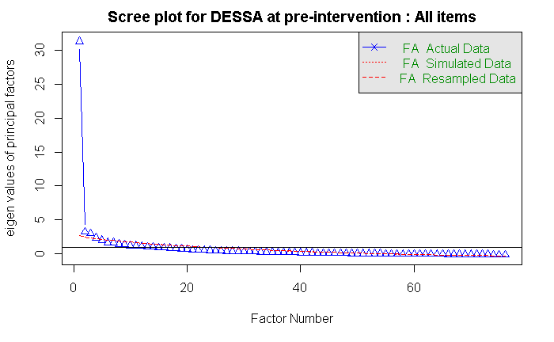

```r
set.seed(Sys.time())
scree_0 = fa.parallel(dessa.time0,
 fm = 'ml',
 fa = 'fa',
 n.iter = 200,
 main = "Scree plot for DESSA at pre-intervention : All items",
 SMC = TRUE)
```

### EFA: Recommended solution. All items

```r
 ##EFA with number of factors as recommended by simulation (using dessa pre-intervention) -Neil
fa(dessa.time0, nfactors = scree_0$nfact, fm = "ml", rotate = "geominQ")
```

```
Factor Analysis using method =  ml
Call: fa(r = dessa.time0, nfactors = scree_0$nfact, rotate = "geominQ",
    fm = "ml")
Standardized loadings (pattern matrix) based upon correlation matrix
             ML1   ML4   ML2   ML3   h2   u2 com
p0dessa_1  -0.02  0.67 -0.15  0.01 0.34 0.66 1.1
p0dessa_2   0.07  0.30  0.37 -0.09 0.41 0.59 2.1
p0dessa_3   0.32  0.08  0.28  0.16 0.39 0.61 2.6
p0dessa_4   0.14  0.17  0.30 -0.10 0.29 0.71 2.3
p0dessa_5  -0.02  0.16  0.38  0.26 0.32 0.68 2.2
p0dessa_6   0.25 -0.09  0.57  0.28 0.57 0.43 1.9
p0dessa_7  -0.01  0.24  0.52  0.31 0.61 0.39 2.1
p0dessa_8   0.33  0.16  0.17  0.26 0.43 0.57 3.0
p0dessa_9   0.01  0.11  0.46  0.34 0.43 0.57 2.0
p0dessa_10  0.39  0.01  0.31  0.45 0.64 0.36 2.8
p0dessa_11  0.35  0.17  0.12  0.39 0.52 0.48 2.6
p0dessa_12  0.16  0.24  0.06  0.34 0.32 0.68 2.3
p0dessa_13  0.18  0.42  0.06  0.33 0.51 0.49 2.3
p0dessa_14  0.02  0.23  0.56 -0.02 0.53 0.47 1.3
p0dessa_15  0.21  0.50  0.08  0.05 0.51 0.49 1.4
p0dessa_16  0.00  0.47  0.27 -0.10 0.44 0.56 1.7
p0dessa_17  0.18  0.41  0.31  0.14 0.65 0.35 2.5
p0dessa_18  0.05  0.71 -0.06  0.03 0.51 0.49 1.0
p0dessa_19  0.31  0.44  0.00  0.13 0.52 0.48 2.0
p0dessa_20  0.21  0.28  0.39  0.06 0.59 0.41 2.5
p0dessa_21  0.36  0.26 -0.09  0.06 0.28 0.72 2.0
p0dessa_22 -0.12  0.71  0.14  0.16 0.59 0.41 1.2
p0dessa_23  0.14  0.47  0.06  0.01 0.38 0.62 1.2
p0dessa_24  0.46  0.02  0.28 -0.05 0.44 0.56 1.7
p0dessa_25  0.57  0.06  0.15 -0.04 0.50 0.50 1.2
p0dessa_26  0.08  0.12  0.59  0.04 0.52 0.48 1.1
p0dessa_27  0.18  0.03  0.58  0.04 0.53 0.47 1.2
p0dessa_28  0.39  0.32  0.12  0.07 0.55 0.45 2.2
p0dessa_29  0.79 -0.25  0.05  0.00 0.44 0.56 1.2
p0dessa_30  0.09  0.56  0.02  0.28 0.53 0.47 1.5
p0dessa_31  0.21  0.01  0.48  0.21 0.46 0.54 1.8
p0dessa_32  0.55  0.23 -0.10  0.06 0.46 0.54 1.4
p0dessa_33  0.07  0.52  0.10  0.19 0.47 0.53 1.4
p0dessa_34  0.73  0.08 -0.10  0.24 0.63 0.37 1.3
p0dessa_35  0.80  0.04 -0.08  0.21 0.68 0.32 1.2
```

[output cut: 62 more lines]

```
The root mean square of the residuals (RMSR) is  0.06
The df corrected root mean square of the residuals is  0.06

The harmonic number of observations is  121 with the empirical chi square  2150.09  with prob <  1
The total number of observations was  121  with Likelihood Chi Square =  3736.31  with prob <  2.9e-48

Tucker Lewis Index of factoring reliability =  0.739
RMSEA index =  0.088  and the 90 % confidence intervals are  0.058 NA
BIC =  -8502.54
Fit based upon off diagonal values = 0.98
Measures of factor score adequacy
                                                   ML1  ML4  ML2  ML3
Correlation of (regression) scores with factors   0.98 0.97 0.98 0.93
Multiple R square of scores with factors          0.96 0.94 0.95 0.86
Minimum correlation of possible factor scores     0.93 0.89 0.90 0.71
```